# Data Science Project(Classification)

Group-04

2026-01-02

#### Dataset: Student Performance Factors

#### Source: Kaggle

#### Link: https://drive.google.com/uc?export=download&id=1IWA5bJ8t7s0pJKCGah4Fg4xVEFWS1SD5

#### Domain: Education

#### Objective: Predict student exam performance grade (Low / Medium / High)

### Load Required Packages

These libraries are used for: - Data manipulation: dplyr, tidyr - Data visualization: ggplot2, corrplot, GGally, scales - Classification modeling: e1071, caret, rpart - Categorical encoding: fastDummies - Feature selection: FSelectorRcpp

```r
packages <- c("ggplot2","dplyr","scales","tidyr","GGally","e1071",
              "fastDummies","FSelectorRcpp","corrplot","caret","rpart")

installed_packages <- rownames(installed.packages())
for(pkg in packages){
  if(!(pkg %in% installed_packages)){
    install.packages(pkg)
  }
  library(pkg, character.only = TRUE)
}
```

# A.Data Collection

### Load dataset directly from URL to avoid local file dependency

This ensures the script runs on any machine without modification and Print dataset

```r
url <- "https://drive.google.com/uc?export=download&id=1IWA5bJ8t7s0pJKCGah4Fg4xVEFWS1SD5"
data <- read.csv(url, stringsAsFactors = FALSE)
head(data)
```

```
##   Hours_Studied Attendance Parental_Involvement Access_to_Resources
## 1            23         84                  Low                High
## 2            19         64                  Low              Medium
## 3            24         98               Medium              Medium
## 4            29         89                  Low              Medium
## 5            19         92               Medium              Medium
## 6            19         88               Medium              Medium
##   Extracurricular_Activities Sleep_Hours Previous_Scores Motivation_Level
## 1                         No           7              73              Low
## 2                         No           8              59              Low
## 3                        Yes           7              91           Medium
## 4                        Yes           8              98           Medium
## 5                        Yes           6              65           Medium
## 6                        Yes           8              89           Medium
##   Internet_Access Tutoring_Sessions Family_Income Teacher_Quality School_Type
```

[output cut: 20 more lines]

# B.Data understanding and Exploration

### To determine how many rows and columns in this dataset and Convert empty strings to NA for consistency

```r
data[data == ""] <- NA
cat("Rows:", nrow(data), "Cols:", ncol(data), "\n")
```

```
## Rows: 6607 Cols: 20
```

### Display dataset structure and summary statistics

To understand data dimensions, data types, and summary statistics.

```r
cat("Names:\n")
```

```
## Names:
```

```r
print(names(data))
```

```
##  [1] "Hours_Studied"              "Attendance"
##  [3] "Parental_Involvement"       "Access_to_Resources"
##  [5] "Extracurricular_Activities" "Sleep_Hours"
##  [7] "Previous_Scores"            "Motivation_Level"
##  [9] "Internet_Access"            "Tutoring_Sessions"
## [11] "Family_Income"              "Teacher_Quality"
## [13] "School_Type"                "Peer_Influence"
## [15] "Physical_Activity"          "Learning_Disabilities"
## [17] "Parental_Education_Level"   "Distance_from_Home"
## [19] "Gender"                     "Exam_Score"
```

```r
cat("Summary:\n")
```

```
## Summary:
```

```r
print(summary(data))
```

```
##  Hours_Studied     Attendance     Parental_Involvement Access_to_Resources
##  Min.   : 1.00   Min.   : 60.00   Length:6607          Length:6607
##  1st Qu.:16.00   1st Qu.: 70.00   Class :character     Class :character
##  Median :20.00   Median : 80.00   Mode  :character     Mode  :character
##  Mean   :19.98   Mean   : 79.98
##  3rd Qu.:24.00   3rd Qu.: 90.00
##  Max.   :44.00   Max.   :100.00
##  Extracurricular_Activities  Sleep_Hours     Previous_Scores
##  Length:6607                Min.   : 4.000   Min.   : 50.00
##  Class :character           1st Qu.: 6.000   1st Qu.: 63.00
##  Mode  :character           Median : 7.000   Median : 75.00
##                             Mean   : 7.029   Mean   : 75.07
##                             3rd Qu.: 8.000   3rd Qu.: 88.00
##                             Max.   :10.000   Max.   :100.00
##  Motivation_Level   Internet_Access    Tutoring_Sessions Family_Income
##  Length:6607        Length:6607        Min.   :0.000     Length:6607
##  Class :character   Class :character   1st Qu.:1.000     Class :character
##  Mode  :character   Mode  :character   Median :1.000     Mode  :character
##                                        Mean   :1.494
##                                        3rd Qu.:2.000
##                                        Max.   :8.000
##  Teacher_Quality    School_Type        Peer_Influence     Physical_Activity
##  Length:6607        Length:6607        Length:6607        Min.   :0.000
##  Class :character   Class :character   Class :character   1st Qu.:2.000
##  Mode  :character   Mode  :character   Mode  :character   Median :3.000
##                                                           Mean   :2.968
##                                                           3rd Qu.:4.000
##                                                           Max.   :6.000
##  Learning_Disabilities Parental_Education_Level Distance_from_Home
##  Length:6607           Length:6607              Length:6607
##  Class :character      Class :character         Class :character
##  Mode  :character      Mode  :character         Mode  :character
##
##
##
##     Gender            Exam_Score
##  Length:6607        Min.   : 55.00
##  Class :character   1st Qu.: 65.00
##  Mode  :character   Median : 67.00
##                     Mean   : 67.24
##                     3rd Qu.: 69.00
##                     Max.   :101.00
```

```r
cat("NA counts:\n")
```

```
## NA counts:
```

```r
print(colSums(is.na(data)))
```

```
##              Hours_Studied                 Attendance
##                          0                          0
##       Parental_Involvement        Access_to_Resources
##                          0                          0
## Extracurricular_Activities                Sleep_Hours
##                          0                          0
##            Previous_Scores           Motivation_Level
##                          0                          0
##            Internet_Access          Tutoring_Sessions
##                          0                          0
##              Family_Income            Teacher_Quality
##                          0                         78
##                School_Type             Peer_Influence
##                          0                          0
##          Physical_Activity      Learning_Disabilities
##                          0                          0
##   Parental_Education_Level         Distance_from_Home
##                         90                         67
##                     Gender                 Exam_Score
##                          0                          0
```

### Identify numerical and categorical features

```r
numeric_cols <- names(data)[sapply(data, is.numeric)]
cat_cols_all_initial <- names(data)[sapply(data, function(x) is.character(x) | is.factor(x))]

cat("Feature Identification (Raw Data)\n")
```

```
## Feature Identification (Raw Data)
```

```r
cat("\nCategorical Features:\n")
```

```
##
## Categorical Features:
```

```r
print(cat_cols_all_initial)
```

```
##  [1] "Parental_Involvement"       "Access_to_Resources"
##  [3] "Extracurricular_Activities" "Motivation_Level"
##  [5] "Internet_Access"            "Family_Income"
##  [7] "Teacher_Quality"            "School_Type"
##  [9] "Peer_Influence"             "Learning_Disabilities"
## [11] "Parental_Education_Level"   "Distance_from_Home"
## [13] "Gender"
```

```r
cat("\nNumerical Features:\n")
```

```
##
## Numerical Features:
```

```r
print(numeric_cols)
```

```
## [1] "Hours_Studied"     "Attendance"        "Sleep_Hours"
## [4] "Previous_Scores"   "Tutoring_Sessions" "Physical_Activity"
## [7] "Exam_Score"
```

### Exploratory Data Analysis (EDA)

Purpose of EDA: 1. Understand distributions of numerical features 2. Detect outliers using boxplots 3. Analyze correlations between variables 4. Examine key relationships with target variable

#### Histograms for Numerical Features

Visualize the distribution of each numerical variable

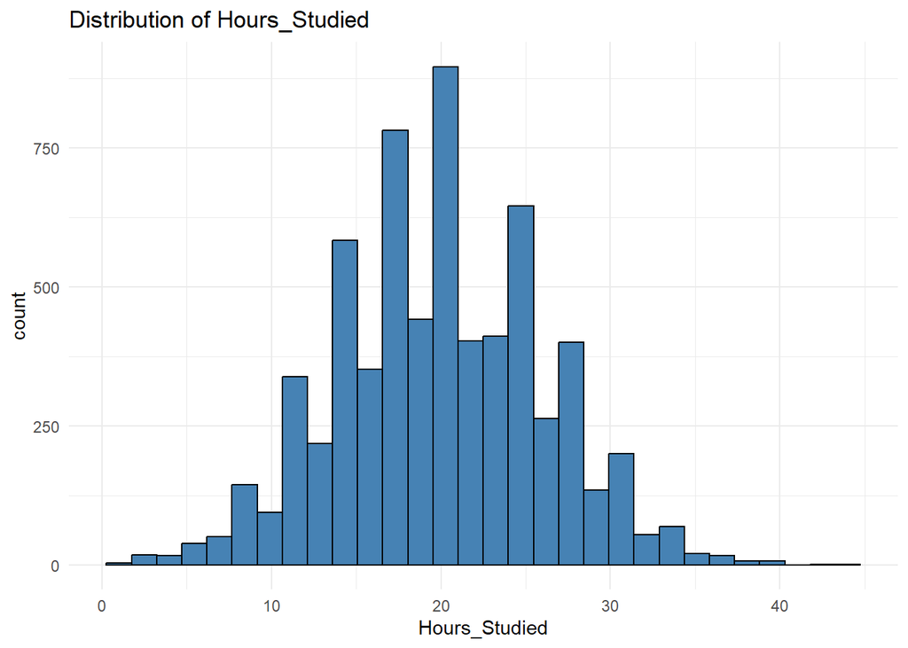

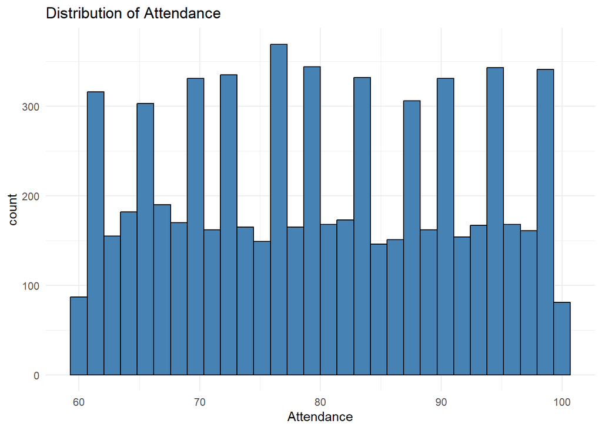

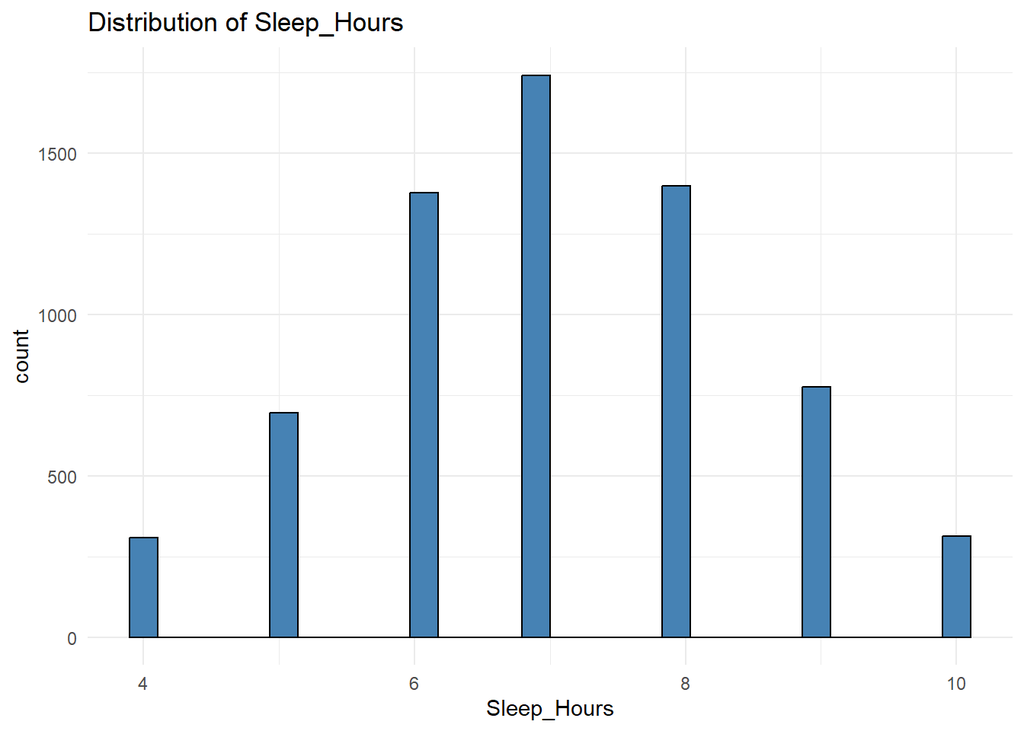

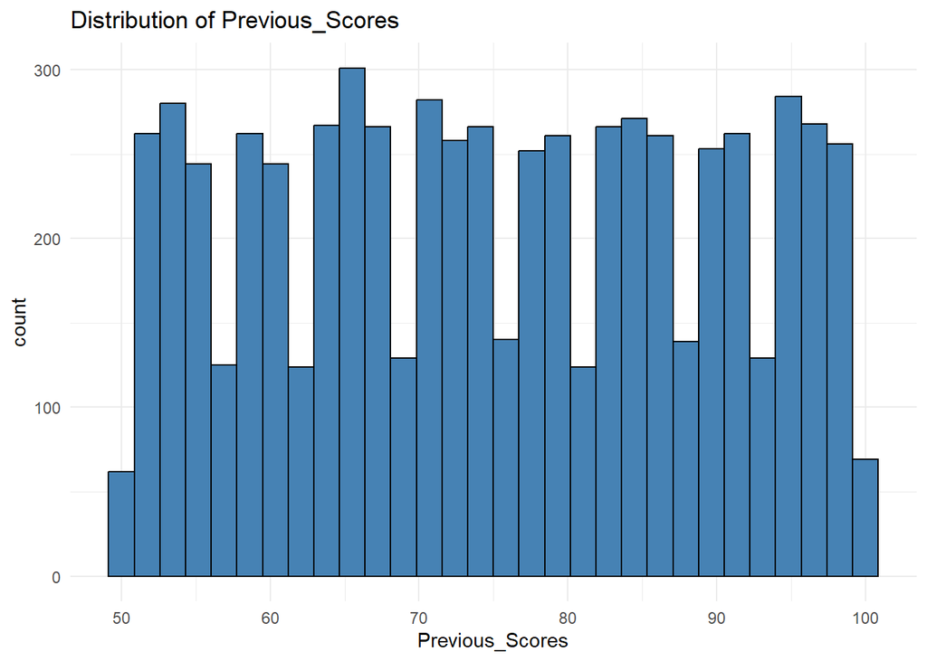

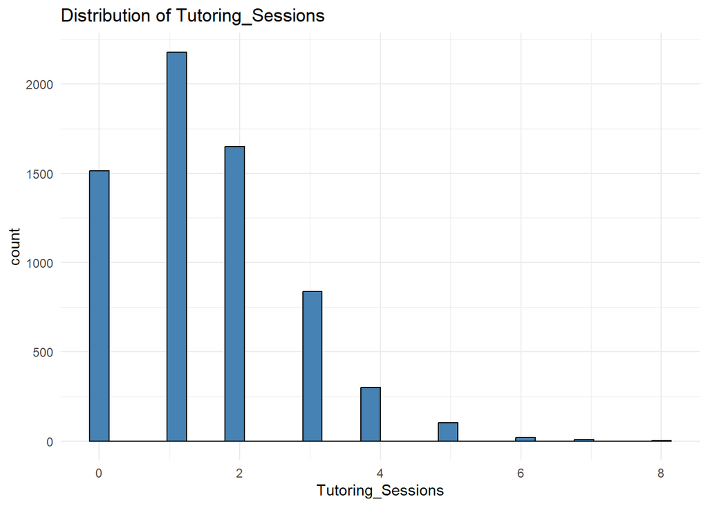

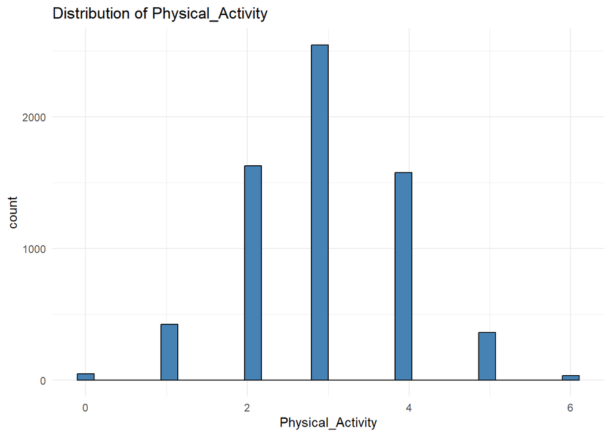

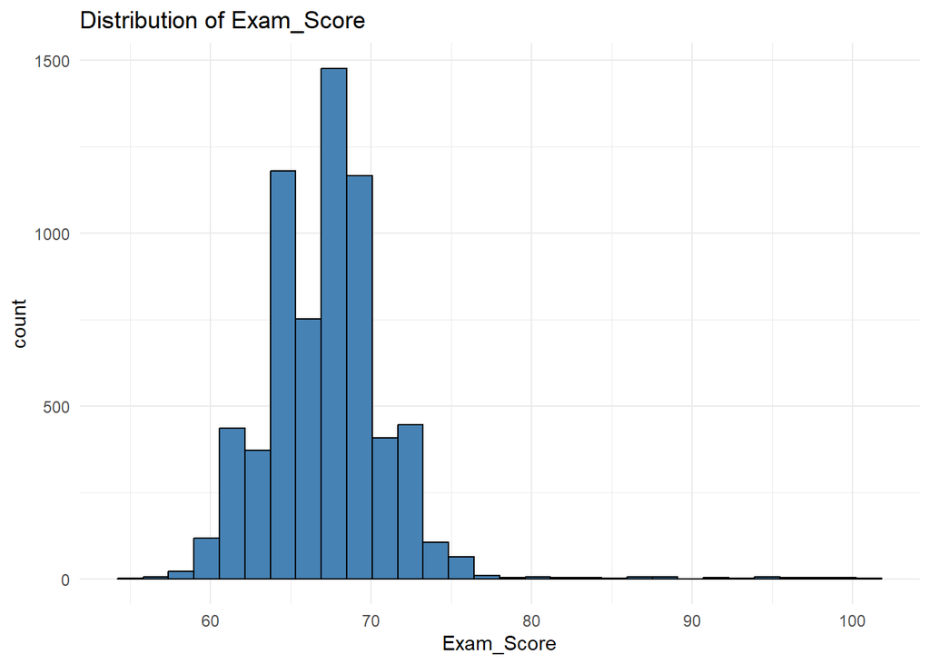

```r
for(col in numeric_cols){
  p <- ggplot(data, aes_string(x = col)) +
    geom_histogram(bins = 30, fill = "steelblue", color = "black") +
    theme_minimal() +
    labs(title = paste("Distribution of", col))
  print(p)
}
```

### Boxplots for Numerical Features

Visualize potential outliers in each numerical variable

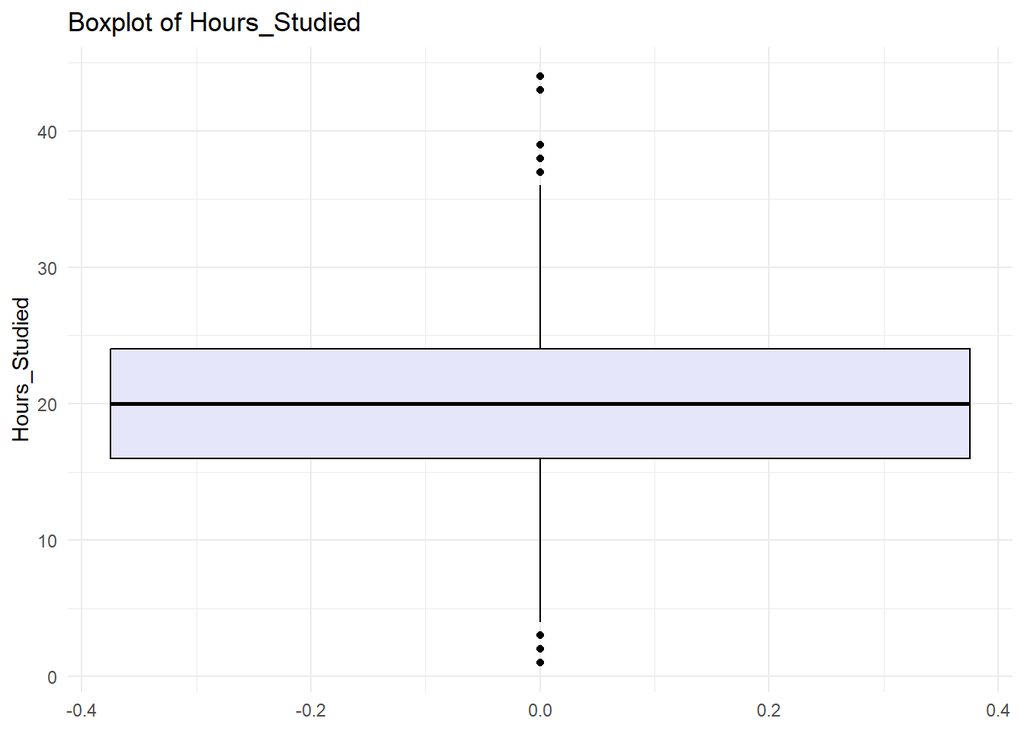

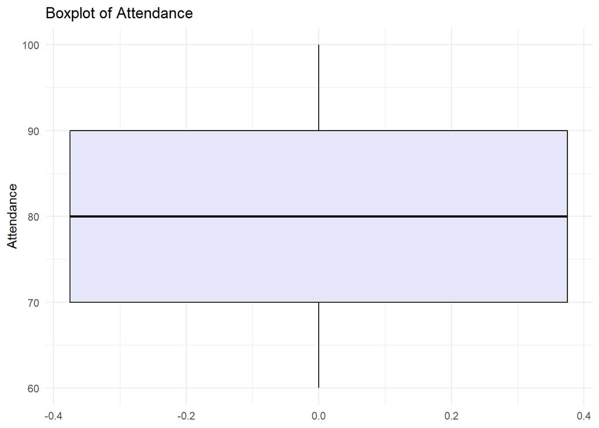

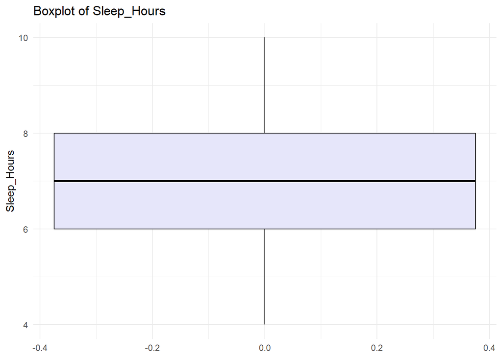

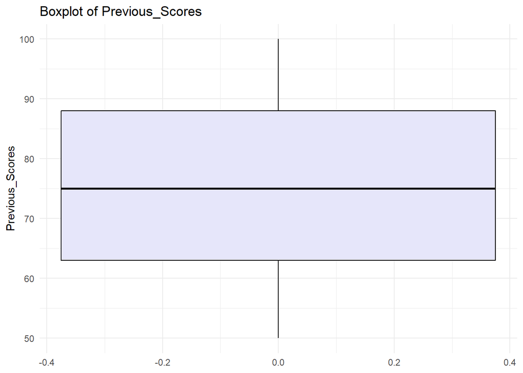

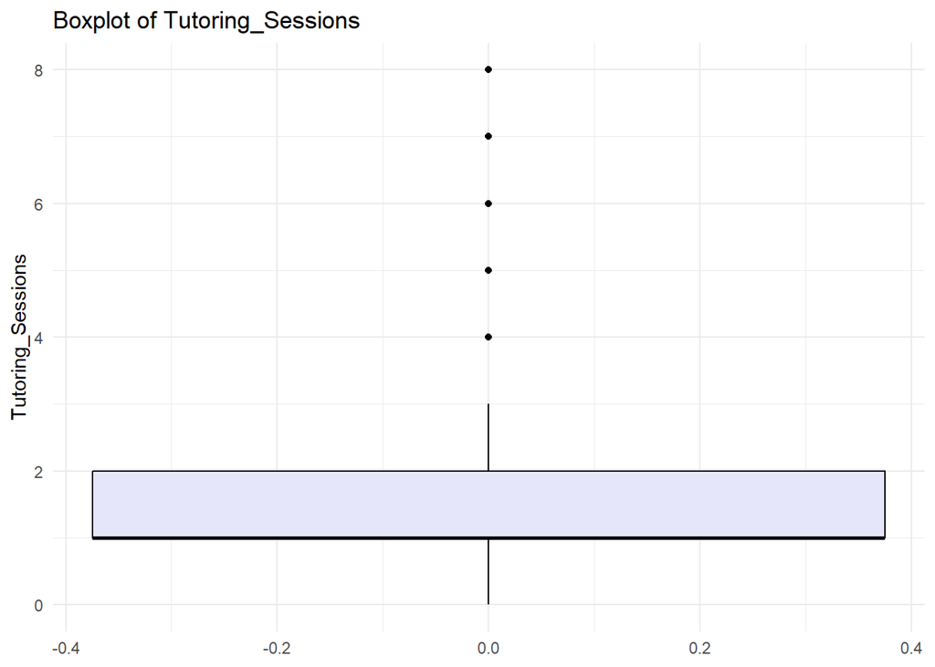

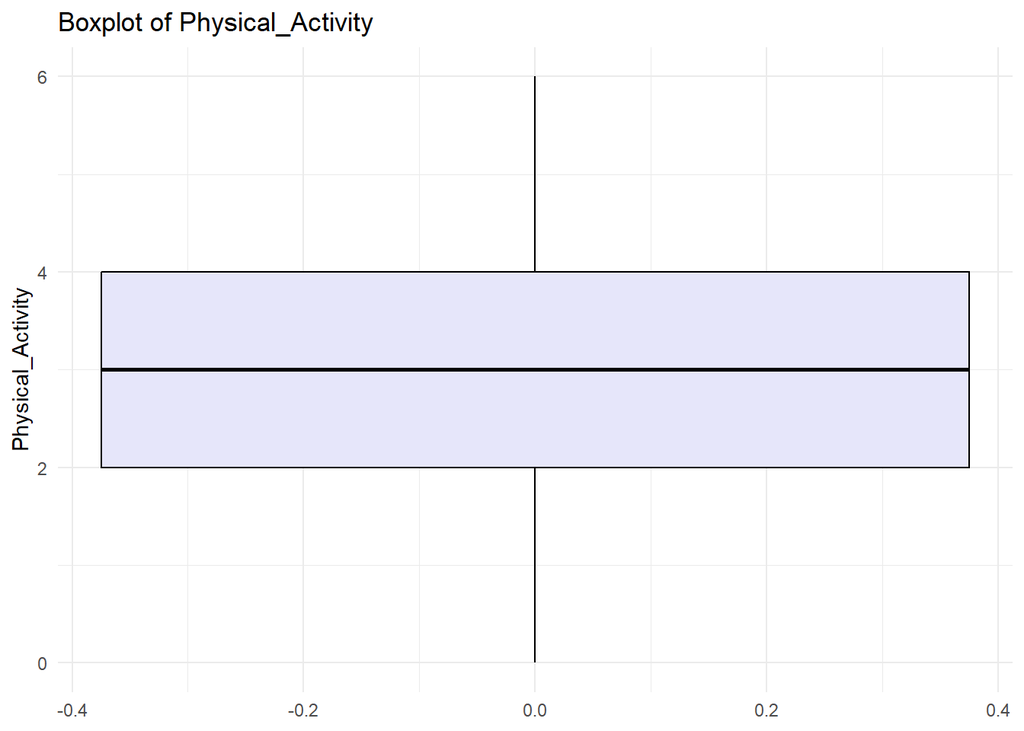

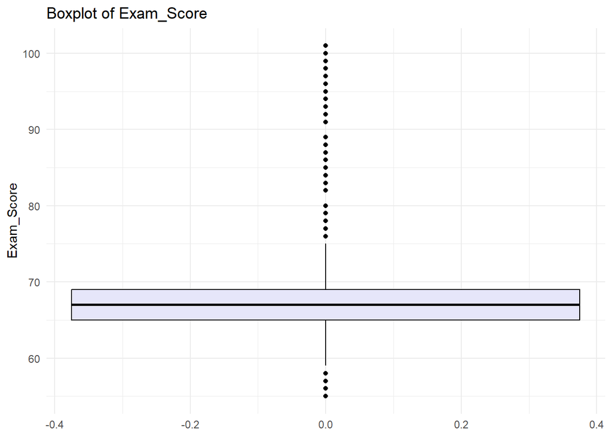

```r
for(col in numeric_cols){
  p <- ggplot(data, aes_string(y = col)) +
    geom_boxplot(fill = "lavender", color = "black") +
    theme_minimal() +
    labs(title = paste("Boxplot of", col))
  print(p)
}
```

### Correlation Analysis

Identify relationships between numerical variables

```
## Correlation Matrix:
##                   Hours_Studied Attendance Sleep_Hours Previous_Scores
## Hours_Studied             1.000     -0.010       0.011           0.025
## Attendance               -0.010      1.000      -0.016          -0.020
## Sleep_Hours               0.011     -0.016       1.000          -0.022
## Previous_Scores           0.025     -0.020      -0.022           1.000
## Tutoring_Sessions        -0.014      0.014      -0.012          -0.013
## Physical_Activity         0.005     -0.022       0.000          -0.011
## Exam_Score                0.445      0.581      -0.017           0.175
##                   Tutoring_Sessions Physical_Activity Exam_Score
## Hours_Studied                -0.014             0.005      0.445
## Attendance                    0.014            -0.022      0.581
## Sleep_Hours                  -0.012             0.000     -0.017
## Previous_Scores              -0.013            -0.011      0.175
## Tutoring_Sessions             1.000             0.018      0.157
## Physical_Activity             0.018             1.000      0.028
## Exam_Score                    0.157             0.028      1.000
```

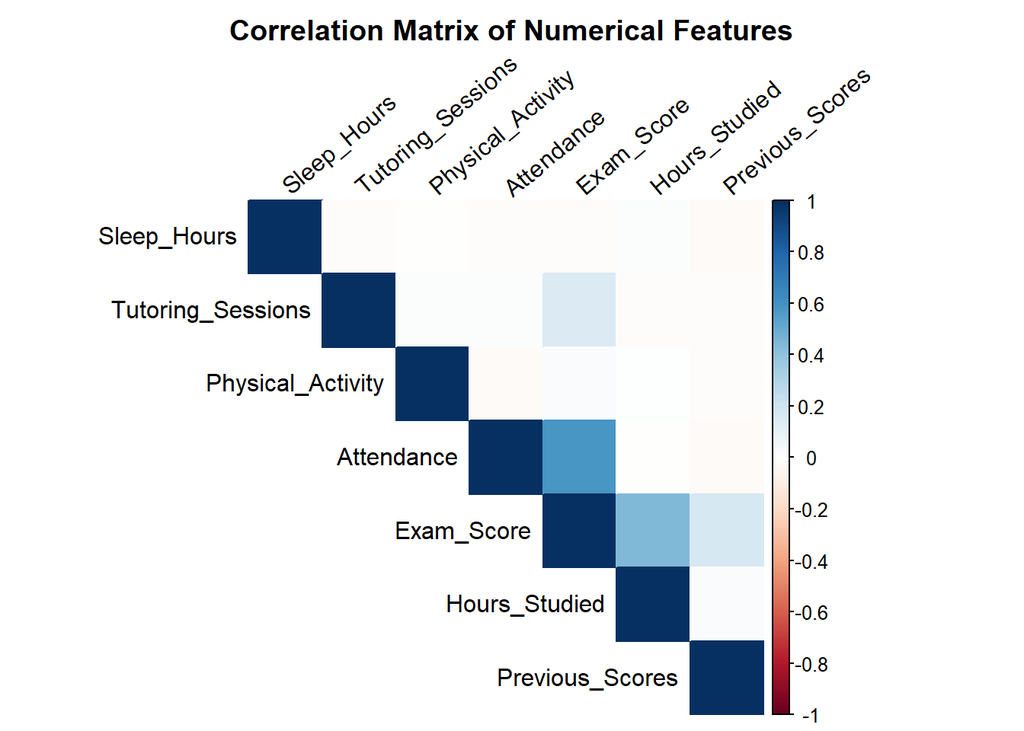

```r
if(length(numeric_cols) > 1){
  cor_mat <- cor(data[, numeric_cols], use = "pairwise.complete.obs")
  cat("Correlation Matrix:\n")
  print(round(cor_mat,3))

  corrplot::corrplot(cor_mat, method = "color", type = "upper",
                     order = "hclust", tl.col = "black", tl.srt = 40,
                     title = "Correlation Matrix of Numerical Features",
                     mar = c(0,0,2,0))
}
```

### Scatter Plots

Examine relationships between important predictors and Exam_Score

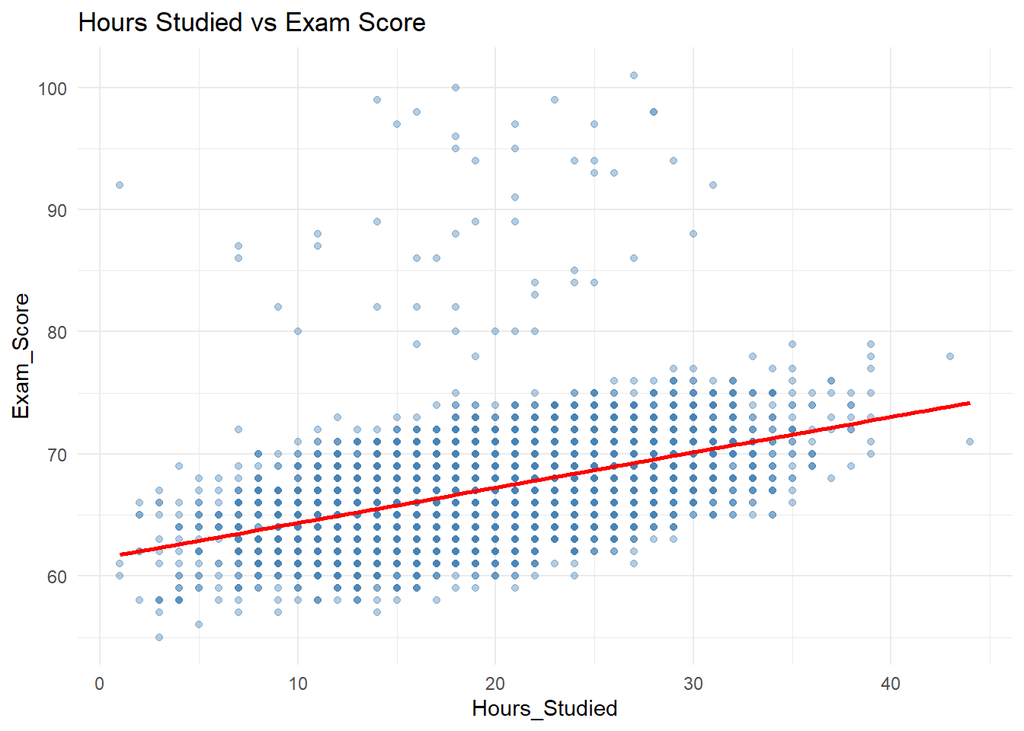

```r
if(all(c("Hours_Studied", "Exam_Score") %in% names(data))){
  p <- ggplot(data, aes(x = Hours_Studied, y = Exam_Score)) +
    geom_point(alpha = 0.4, color = "steelblue") +
    geom_smooth(method = "lm", se = FALSE, color = "red") +
    theme_minimal() +
    labs(title = "Hours Studied vs Exam Score")
  print(p)
}
```

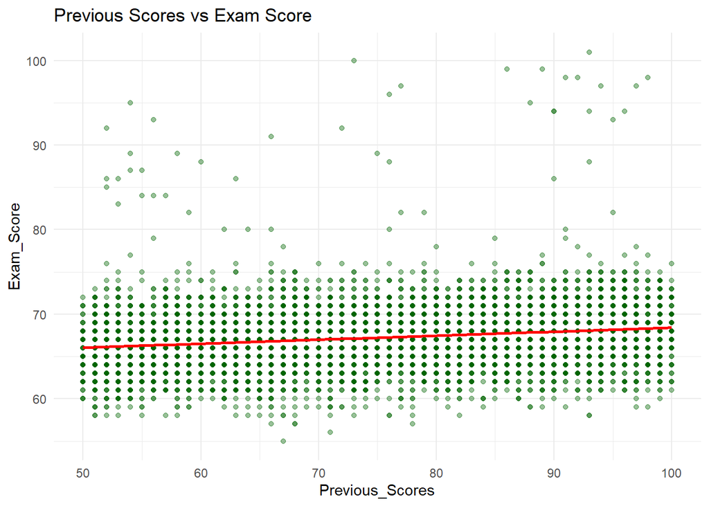

```r
if(all(c("Previous_Scores", "Exam_Score") %in% names(data))){
  p <- ggplot(data, aes(x = Previous_Scores, y = Exam_Score)) +
    geom_point(alpha = 0.4, color = "darkgreen") +
    geom_smooth(method = "lm", se = FALSE, color = "red") +
    theme_minimal() +
    labs(title = "Previous Scores vs Exam Score")
  print(p)
}
```

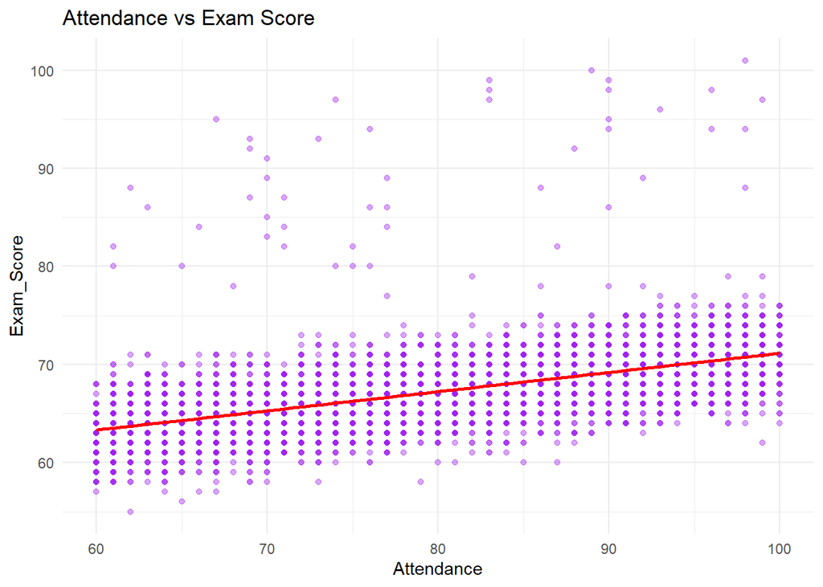

```r
if(all(c("Attendance", "Exam_Score") %in% names(data))){
  p <- ggplot(data, aes(x = Attendance, y = Exam_Score)) +
    geom_point(alpha = 0.4, color = "purple") +
    geom_smooth(method = "lm", se = FALSE, color = "red") +
    theme_minimal() +
    labs(title = "Attendance vs Exam Score")
  print(p)
}
```

# C. Data Preprocessing

### Missing Value Handling

Numerical features → Median (robust to outliers) Categorical features → Mode (most frequent value)

```r
impute_mode <- function(x){
  ux <- na.omit(unique(x))
  if(length(ux) == 0) return(NA)
  ux[which.max(tabulate(match(x, ux)))]
}

data_clean <- data
num_cols_all <- names(data_clean)[sapply(data_clean, is.numeric)]
for(col in num_cols_all){
  if(any(is.na(data_clean[[col]]))){
    data_clean[[col]][is.na(data_clean[[col]])] <- median(data_clean[[col]], na.rm = TRUE)
  }
}

cat_cols_all <- names(data_clean)[sapply(data_clean, function(x) is.character(x) | is.factor(x))]
for(col in cat_cols_all){
  if(any(is.na(data_clean[[col]]))){
    data_clean[[col]][is.na(data_clean[[col]])] <- impute_mode(data_clean[[col]])
  }
}

cat("Feature Identification (After Cleaning)\n")
```

```
## Feature Identification (After Cleaning)
```

```r
cat("\nCategorical Features:\n")
```

```
##
## Categorical Features:
```

```r
print(cat_cols_all)
```

```
##  [1] "Parental_Involvement"       "Access_to_Resources"
##  [3] "Extracurricular_Activities" "Motivation_Level"
##  [5] "Internet_Access"            "Family_Income"
##  [7] "Teacher_Quality"            "School_Type"
##  [9] "Peer_Influence"             "Learning_Disabilities"
## [11] "Parental_Education_Level"   "Distance_from_Home"
## [13] "Gender"
```

```r
cat("\nNumerical Features:\n")
```

```
##
## Numerical Features:
```

```r
print(num_cols_all)
```

```
## [1] "Hours_Studied"     "Attendance"        "Sleep_Hours"
## [4] "Previous_Scores"   "Tutoring_Sessions" "Physical_Activity"
## [7] "Exam_Score"
```

### Remove Duplicate Rows

```r
data_clean <- data_clean[!duplicated(data_clean), ]
```

### Feature Engineering

Creating new feature: Study_Efficiency

```r
if(all(c("Exam_Score","Hours_Studied") %in% names(data_clean))){
  data_clean <- data_clean %>%
    mutate(Study_Efficiency = ifelse(is.na(Hours_Studied) | Hours_Studied==0,
                                     NA, Exam_Score/Hours_Studied))
}
```

### Outlier Handling (IQR Capping)

Outliers can heavily influence model performance. IQR-based capping reduces extreme values without removing data points.

```r
num_cols_clean <- names(data_clean)[sapply(data_clean, is.numeric)]
for(col in num_cols_clean){
  Q1 <- quantile(data_clean[[col]], 0.25, na.rm = TRUE)
  Q3 <- quantile(data_clean[[col]], 0.75, na.rm = TRUE)
  IQR_val <- Q3 - Q1
  lb <- Q1 - 1.5 * IQR_val
  ub <- Q3 + 1.5 * IQR_val
  data_clean[[col]] <- ifelse(data_clean[[col]] < lb, lb,
                              ifelse(data_clean[[col]] > ub, ub, data_clean[[col]]))
}
```

### Encode Categorical Variables

One-hot encoding converts categorical variables to numerical format.

```r
cat_cols_to_encode <- names(data_clean)[sapply(data_clean, function(x) is.character(x) | is.factor(x))]
if(length(cat_cols_to_encode) > 0){
  data_encoded <- fastDummies::dummy_cols(data_clean,
                                          select_columns = cat_cols_to_encode,
                                          remove_first_dummy = TRUE,
                                          remove_selected_columns = TRUE)
} else {
  data_encoded <- data_clean
}

data_encoded <- data_encoded %>%
  mutate(across(where(is.factor), as.numeric)) %>%
  mutate(across(where(is.logical), as.numeric))
```

### Data Transformation and Scaling

Apply logarithmic or square root transformations to skewed features. Standardization ensures all predictors are on the same scale.

```r
num_cols_encoded <- names(data_encoded)[sapply(data_encoded, is.numeric)]
for(col in num_cols_encoded){
  unique_vals <- unique(na.omit(data_encoded[[col]]))
  if(length(unique_vals) <= 2) next
  sk <- e1071::skewness(data_encoded[[col]], na.rm = TRUE)
  if(!is.na(sk) && sk > 1){
    data_encoded[[paste0(col,"_log")]] <- log1p(pmax(0, data_encoded[[col]]))
  } else if(!is.na(sk) && sk > 0.5){
    data_encoded[[paste0(col,"_sqrt")]] <- sqrt(pmax(0, data_encoded[[col]]))
  }
}

final_numeric_cols <- names(data_encoded)[sapply(data_encoded, is.numeric)]
scale_cols <- setdiff(final_numeric_cols, "Exam_Score")
if(length(scale_cols) > 0) data_encoded[scale_cols] <- scale(data_encoded[scale_cols])

data_final_for_fs <- data_encoded
```

### Feature Selection

Feature selection helps identify the most important predictors and reduces model complexity.

#### Correlation-based Feature Analysis

```r
numeric_cols<-names(data_final_for_fs)[sapply(data_final_for_fs,is.numeric)]
cor_matrix<-cor(data_final_for_fs[,numeric_cols],use="pairwise.complete.obs")

for(col in numeric_cols){
  cor_list<-sort(abs(cor_matrix[col,]),decreasing=TRUE)
  cor_list_sorted<-cor_list[names(cor_list)!=col]
  cat("Column:",col,"\n")
  cat("Most correlated feature:",names(cor_list_sorted)[1],
      "with correlation=",round(cor_list_sorted[1],3),"\n")
}
```

```
## Column: Hours_Studied
## Most correlated feature: Study_Efficiency_sqrt with correlation= 0.961
## Column: Attendance
## Most correlated feature: Exam_Score with correlation= 0.661
## Column: Sleep_Hours
## Most correlated feature: Previous_Scores with correlation= 0.022
## Column: Previous_Scores
## Most correlated feature: Exam_Score with correlation= 0.196
## Column: Tutoring_Sessions
## Most correlated feature: Exam_Score with correlation= 0.17
## Column: Physical_Activity
## Most correlated feature: Access_to_Resources_Medium with correlation= 0.039
## Column: Exam_Score
## Most correlated feature: Attendance with correlation= 0.661
## Column: Study_Efficiency
## Most correlated feature: Study_Efficiency_sqrt with correlation= 0.997
## Column: Parental_Involvement_Low
## Most correlated feature: Parental_Involvement_Medium with correlation= 0.513
## Column: Parental_Involvement_Medium
## Most correlated feature: Parental_Involvement_Low with correlation= 0.513
## Column: Access_to_Resources_Low
## Most correlated feature: Access_to_Resources_Medium with correlation= 0.5
## Column: Access_to_Resources_Medium
## Most correlated feature: Access_to_Resources_Low with correlation= 0.5
## Column: Extracurricular_Activities_Yes
## Most correlated feature: Exam_Score with correlation= 0.068
## Column: Motivation_Level_Low
## Most correlated feature: Motivation_Level_Medium with correlation= 0.653
## Column: Motivation_Level_Medium
## Most correlated feature: Motivation_Level_Low with correlation= 0.653
## Column: Internet_Access_Yes
## Most correlated feature: Exam_Score with correlation= 0.063
## Column: Family_Income_Low
## Most correlated feature: Family_Income_Medium with correlation= 0.678
## Column: Family_Income_Medium
## Most correlated feature: Family_Income_Low with correlation= 0.678
## Column: Teacher_Quality_Low
## Most correlated feature: Teacher_Quality_Medium with correlation= 0.412
## Column: Teacher_Quality_Medium
## Most correlated feature: Teacher_Quality_Low with correlation= 0.412
## Column: School_Type_Public
## Most correlated feature: Access_to_Resources_Medium with correlation= 0.026
## Column: Peer_Influence_Neutral
## Most correlated feature: Peer_Influence_Positive with correlation= 0.655
## Column: Peer_Influence_Positive
## Most correlated feature: Peer_Influence_Neutral with correlation= 0.655
## Column: Learning_Disabilities_Yes
## Most correlated feature: Exam_Score with correlation= 0.1
## Column: Parental_Education_Level_High School
## Most correlated feature: Parental_Education_Level_Postgraduate with correlation= 0.498
## Column: Parental_Education_Level_Postgraduate
## Most correlated feature: Parental_Education_Level_High School with correlation= 0.498
## Column: Distance_from_Home_Moderate
## Most correlated feature: Distance_from_Home_Near with correlation= 0.803
## Column: Distance_from_Home_Near
## Most correlated feature: Distance_from_Home_Moderate with correlation= 0.803
## Column: Gender_Male
## Most correlated feature: Parental_Involvement_Medium with correlation= 0.021
## Column: Study_Efficiency_sqrt
## Most correlated feature: Study_Efficiency with correlation= 0.997
```

### Variance Thresholding

Low-variance features usually carry little predictive power.

```r
var_values<-sapply(data_final_for_fs[,numeric_cols,drop=FALSE],var)
threshold <- median(var_values, na.rm = TRUE) * 0.01
selected_features_var<-names(var_values[var_values>threshold])
cat("Features selected by variance threshold:\n")
```

```
## Features selected by variance threshold:
```

```r
print(selected_features_var)
```

```
##  [1] "Hours_Studied"
##  [2] "Attendance"
##  [3] "Sleep_Hours"
##  [4] "Previous_Scores"
##  [5] "Tutoring_Sessions"
##  [6] "Physical_Activity"
##  [7] "Exam_Score"
##  [8] "Study_Efficiency"
##  [9] "Parental_Involvement_Low"
## [10] "Parental_Involvement_Medium"
## [11] "Access_to_Resources_Low"
## [12] "Access_to_Resources_Medium"
## [13] "Extracurricular_Activities_Yes"
## [14] "Motivation_Level_Low"
## [15] "Motivation_Level_Medium"
## [16] "Internet_Access_Yes"
## [17] "Family_Income_Low"
## [18] "Family_Income_Medium"
## [19] "Teacher_Quality_Low"
## [20] "Teacher_Quality_Medium"
## [21] "School_Type_Public"
## [22] "Peer_Influence_Neutral"
## [23] "Peer_Influence_Positive"
## [24] "Learning_Disabilities_Yes"
## [25] "Parental_Education_Level_High School"
## [26] "Parental_Education_Level_Postgraduate"
## [27] "Distance_from_Home_Moderate"
## [28] "Distance_from_Home_Near"
## [29] "Gender_Male"
## [30] "Study_Efficiency_sqrt"
```

### Mutual Information Feature Selection

Mutual information selects features with (possibly non-linear) association with the target.

```r
mi_scores<-FSelectorRcpp::information_gain(Exam_Score ~ ., data = data_final_for_fs[, c(numeric_cols, "Exam_Score")])
mi_selected<-mi_scores$attributes[mi_scores$importance>0]
cat("Features selected by mutual information (Exam_Score):\n")
```

```
## Features selected by mutual information (Exam_Score):
```

```r
print(mi_selected)
```

```
## [1] "Hours_Studied"           "Attendance"
## [3] "Previous_Scores"         "Tutoring_Sessions"
## [5] "Study_Efficiency"        "Access_to_Resources_Low"
## [7] "Study_Efficiency_sqrt"   "Exam_Score.1"
```

### Additional Mutual Information Analysis

```r
if("Previous_Scores" %in% names(data_final_for_fs)){
  mi_scores_prev<-FSelectorRcpp::information_gain(Previous_Scores ~ ., data = data_final_for_fs[, c(numeric_cols, "Previous_Scores")])
  mi_selected_prev<-mi_scores_prev$attributes[mi_scores_prev$importance>0]
  cat("Features selected by mutual information (Previous_Scores):\n")
  print(mi_selected_prev)
}
```

```
## Features selected by mutual information (Previous_Scores):
## [1] "Previous_Scores.1"
```

```r
if("Hours_Studied" %in% names(data_final_for_fs)){
  mi_scores_hours<-FSelectorRcpp::information_gain(Hours_Studied ~ ., data = data_final_for_fs[, c(numeric_cols, "Hours_Studied")])
  mi_selected_hours<-mi_scores_hours$attributes[mi_scores_hours$importance>0]
  cat("Features selected by mutual information (Hours_Studied):\n")
  print(mi_selected_hours)
}
```

```
## Features selected by mutual information (Hours_Studied):
## [1] "Exam_Score"            "Study_Efficiency"      "Study_Efficiency_sqrt"
## [4] "Hours_Studied.1"
```

```r
if("Attendance" %in% names(data_final_for_fs)){
  mi_scores_att<-FSelectorRcpp::information_gain(Attendance ~ ., data = data_final_for_fs[, c(numeric_cols, "Attendance")])
  mi_selected_att<-mi_scores_att$attributes[mi_scores_att$importance>0]
  cat("Features selected by mutual information (Attendance):\n")
  print(mi_selected_att)
}
```

```
## Features selected by mutual information (Attendance):
## [1] "Exam_Score"   "Attendance.1"
```

### Final Feature Selection

```r
chosen_by_var <- selected_features_var
chosen_by_mi <- mi_selected
final_chosen <- unique(c(chosen_by_var, chosen_by_mi))
final_chosen <- intersect(final_chosen, names(data_final_for_fs))

if(length(final_chosen)==0){
  cat("No features auto-selected. Please inspect above outputs and choose features manually.\n")
} else {
  data_for_model <- data_final_for_fs[, c(final_chosen, "Exam_Score"), drop = FALSE]
  cat("Final dataset dimensions:", dim(data_for_model)[1], "rows ×", dim(data_for_model)[2], "columns\n")
}
```

```
## Final dataset dimensions: 6607 rows × 31 columns
```

# D.Modeling

### Data Preparation for Classification

```r
if(exists("data_for_model")){
  cls_data <- data_for_model
} else {
  cls_data <- data_final_for_fs
}

if(!"Exam_Score" %in% names(cls_data)) stop("Exam_Score not found for classification task")

cls_data <- na.omit(cls_data)

cat("\nNA counts in classification data after na.omit:\n")
```

```
##
## NA counts in classification data after na.omit:
```

```r
print(colSums(is.na(cls_data)))
```

```
##                         Hours_Studied                            Attendance
##                                     0                                     0
##                           Sleep_Hours                       Previous_Scores
##                                     0                                     0
##                     Tutoring_Sessions                     Physical_Activity
##                                     0                                     0
##                            Exam_Score                      Study_Efficiency
##                                     0                                     0
##              Parental_Involvement_Low           Parental_Involvement_Medium
##                                     0                                     0
##               Access_to_Resources_Low            Access_to_Resources_Medium
##                                     0                                     0
##        Extracurricular_Activities_Yes                  Motivation_Level_Low
##                                     0                                     0
##               Motivation_Level_Medium                   Internet_Access_Yes
##                                     0                                     0
##                     Family_Income_Low                  Family_Income_Medium
##                                     0                                     0
##                   Teacher_Quality_Low                Teacher_Quality_Medium
##                                     0                                     0
##                    School_Type_Public                Peer_Influence_Neutral
##                                     0                                     0
##               Peer_Influence_Positive             Learning_Disabilities_Yes
##                                     0                                     0
##  Parental_Education_Level_High School Parental_Education_Level_Postgraduate
##                                     0                                     0
##           Distance_from_Home_Moderate               Distance_from_Home_Near
##                                     0                                     0
##                           Gender_Male                 Study_Efficiency_sqrt
##                                     0                                     0
##                          Exam_Score.1
##                                     0
```

```r
cls_data <- cls_data %>% mutate(across(where(is.character), as.factor))
```

### Create Target Variable (Grade Categories)

Convert continuous Exam_Score to categorical grades: Low (<65), Medium (65-69), High (>=70)

```r
cls_data$Grade <- cut(cls_data$Exam_Score,
                      breaks = c(-Inf, 64, 69, Inf),
                      labels = c("Low", "Medium", "High"))
```

### Train-Test Split

70% training, 30% testing

```r
set.seed(123)
modeling_data <- cls_data %>% select(-Exam_Score)
trainIndex <- caret::createDataPartition(modeling_data$Grade, p = 0.7, list = FALSE)
trainData <- modeling_data[trainIndex, ]
testData  <- modeling_data[-trainIndex, ]
```

### Decision Tree Model

Decision Tree is used because the target variable is categorical.

```r
model_dt <- rpart(Grade ~ ., data = trainData, method = "class")
print(model_dt)
```

```
## n= 4626
##
## node), split, n, loss, yval, (yprob)
##       * denotes terminal node
##
## 1) root 4626 2155 Medium (0.2198444 0.5341548 0.2460009)
##   2) Exam_Score.1< 69.5 3488 1017 Medium (0.2915711 0.7084289 0.0000000)
##     4) Exam_Score.1< 64.5 1017    0 Low (1.0000000 0.0000000 0.0000000) *
##     5) Exam_Score.1>=64.5 2471    0 Medium (0.0000000 1.0000000 0.0000000) *
##   3) Exam_Score.1>=69.5 1138    0 High (0.0000000 0.0000000 1.0000000) *
```

### Model Predictions

```r
pred_dt <- predict(model_dt, newdata = testData, type = "class")
```

# E.Evaluation

```r
conf_mat <- confusionMatrix(pred_dt, testData$Grade)
print(conf_mat)
```

```
## Confusion Matrix and Statistics
##
##           Reference
## Prediction  Low Medium High
##     Low     435      0    0
##     Medium    0   1059    0
##     High      0      0  487
##
## Overall Statistics
##
##                Accuracy : 1
##                  95% CI : (0.9981, 1)
##     No Information Rate : 0.5346
##     P-Value [Acc > NIR] : < 2.2e-16
##
##                   Kappa : 1
##
##  Mcnemar's Test P-Value : NA
##
## Statistics by Class:
##
##                      Class: Low Class: Medium Class: High
## Sensitivity              1.0000        1.0000      1.0000
## Specificity              1.0000        1.0000      1.0000
## Pos Pred Value           1.0000        1.0000      1.0000
## Neg Pred Value           1.0000        1.0000      1.0000
## Prevalence               0.2196        0.5346      0.2458
## Detection Rate           0.2196        0.5346      0.2458
## Detection Prevalence     0.2196        0.5346      0.2458
## Balanced Accuracy        1.0000        1.0000      1.0000
```

```r
accuracy <- conf_mat$overall['Accuracy']
cat("Decision Tree Accuracy:", round(accuracy, 4), "\n")
```

```
## Decision Tree Accuracy: 1
```

### Multi-class Performance Metrics

```r
cat("\n=== Model Performance Metrics (Multi-class) ===\n")
```

```
##
## === Model Performance Metrics (Multi-class) ===
```

```r
precision <- mean(conf_mat$byClass[, "Precision"], na.rm = TRUE)
recall    <- mean(conf_mat$byClass[, "Recall"],    na.rm = TRUE)
f1_score  <- mean(conf_mat$byClass[, "F1"],        na.rm = TRUE)

cat("Macro Precision:", round(precision, 4), "\n")
```

```
## Macro Precision: 1
```

```r
cat("Macro Recall   :", round(recall, 4), "\n")
```

```
## Macro Recall   : 1
```

```r
cat("Macro F1-Score :", round(f1_score, 4), "\n")
```

```
## Macro F1-Score : 1
```

### Confusion Matrix Visualization

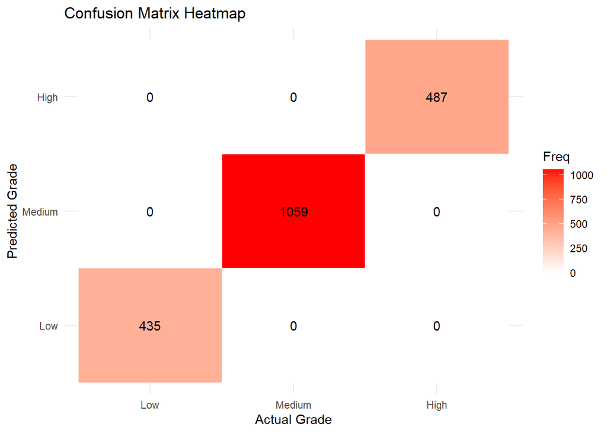

```r
cm_table <- as.data.frame(conf_mat$table)
names(cm_table) <- c("Predicted", "Actual", "Freq")

p <- ggplot(cm_table, aes(x = Actual, y = Predicted, fill = Freq)) +
  geom_tile(color = "white") +
  geom_text(aes(label = Freq), color = "black") +
  scale_fill_gradient(low = "white", high = "red") +
  theme_minimal() +
  labs(title = "Confusion Matrix Heatmap", x = "Actual Grade", y = "Predicted Grade")
print(p)
```